# DETECTR 033 Envision Overnight 384 Black Plate

## NEBuffer 4+ 2.1 Fresh Standard Curves for concentrations from 0.01uM to 10uM, including 0uM

- 0hr (plate repeat 1) and 1hr (plate repeat 9) single time points are first two plots
- Summation of all data points below 1hr (9), 3hr (26), 6hr (51) and 11.5hr (99) are next four plots

### Conclusion

For all samples, summing up all rfu values that came before a certain timepoint gives no noticeable gains on the R2 value. There is significant difference between the replicates. 10uM doesn’t seem out of the linear range on the Envision.

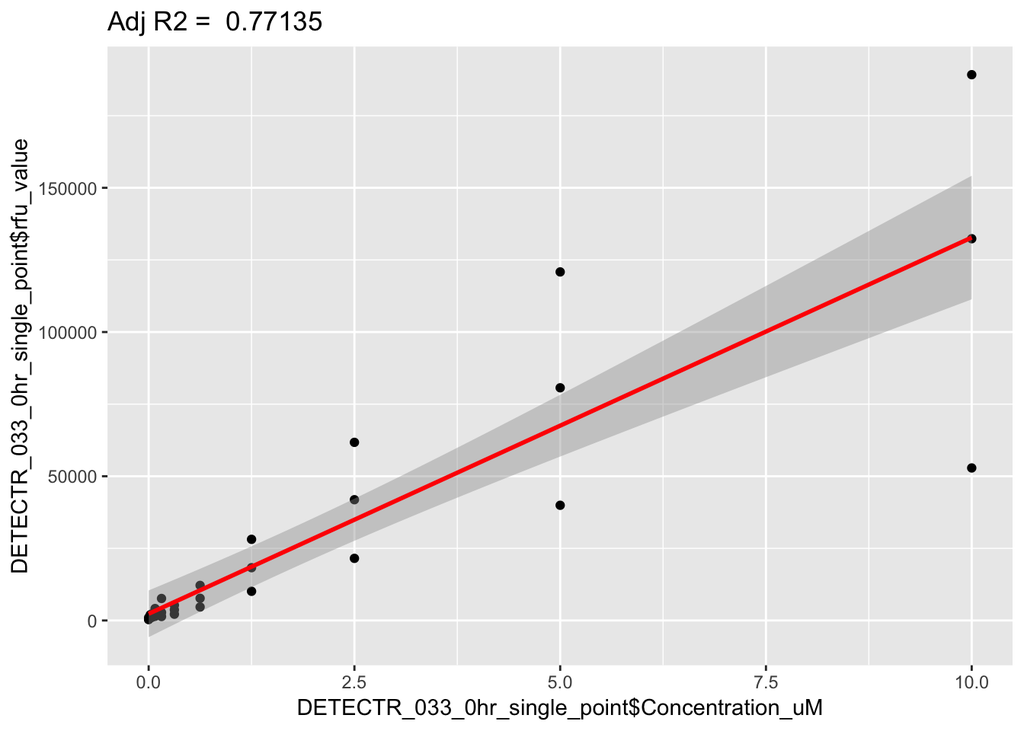

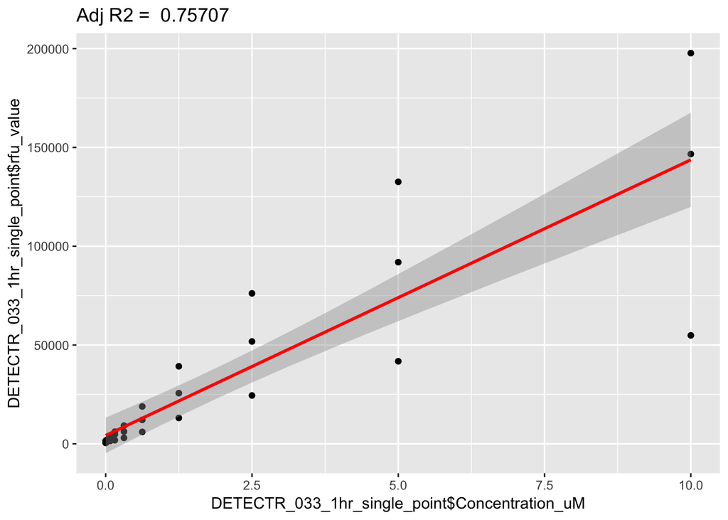

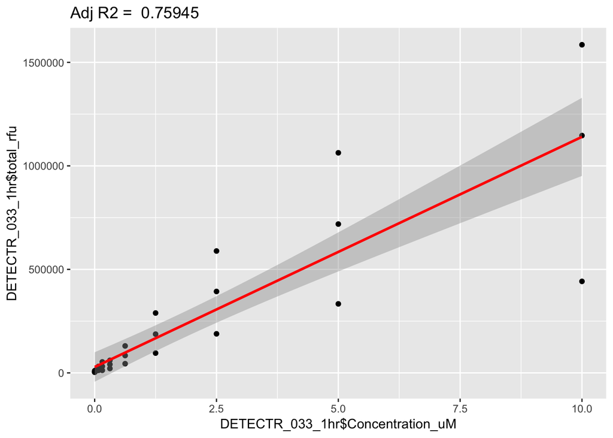

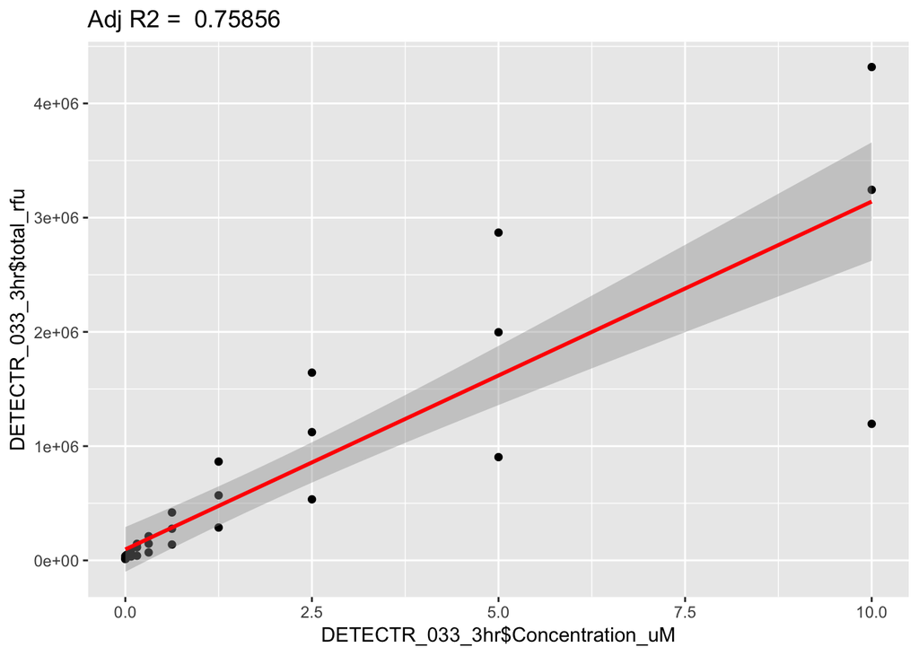

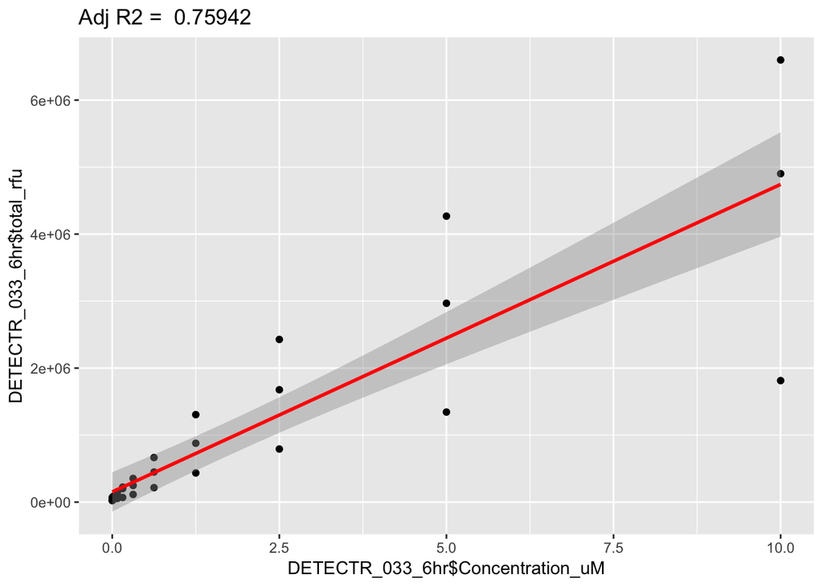

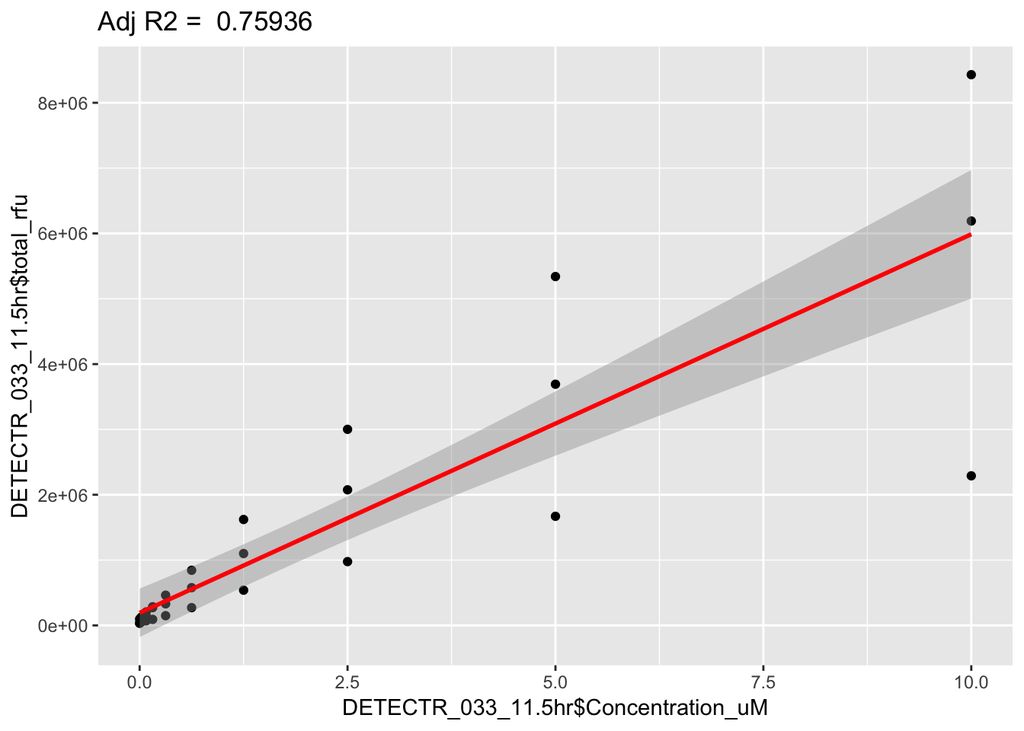

## NEBuffer 4+ 2.1 Fresh Standard Curves for concentrations from 0.01uM to 0.625uM, including 0uM

- 0hr (plate repeat 1) and 1hr (plate repeat 9) single time points are first two plots
- Summation of all data points below 1hr (9), 3hr (26), 6hr (51) and 11.5hr (99) are next four plots

### Conclusion

For lower concentration samples, summing up all rfu values that came before a certain timepoint gives no noticeable gains on the R2 value. Hard to tell if Envision is more sensitive than SpectraMax.

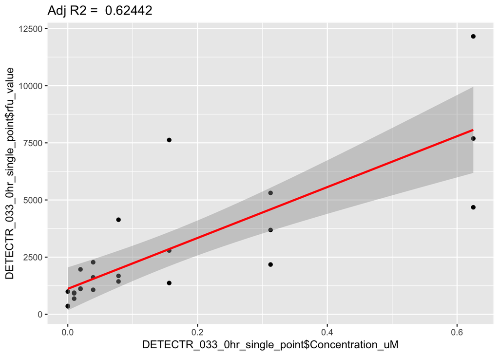

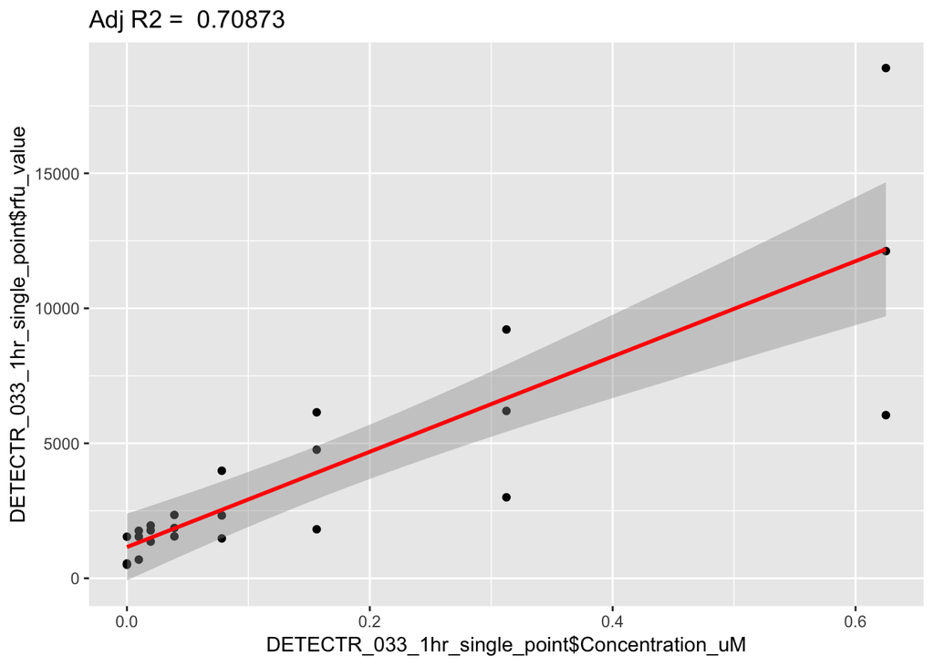

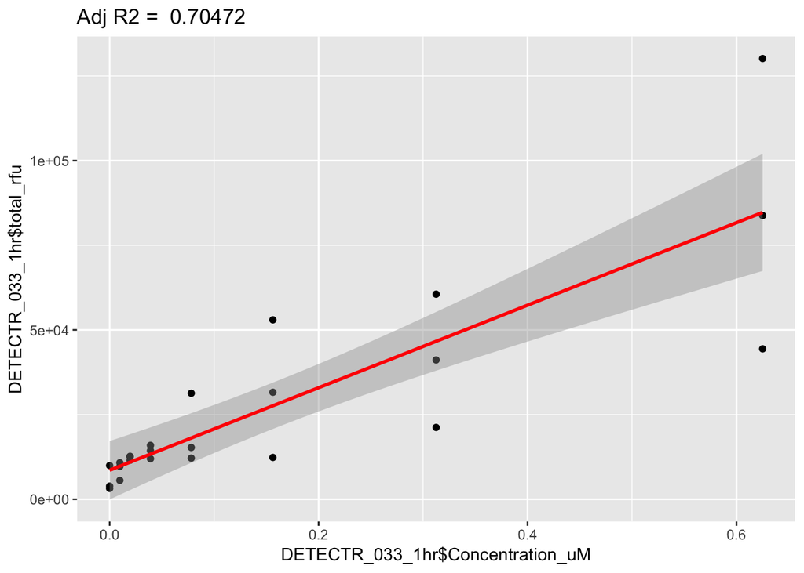

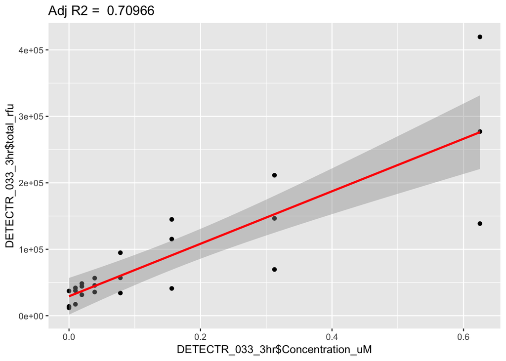

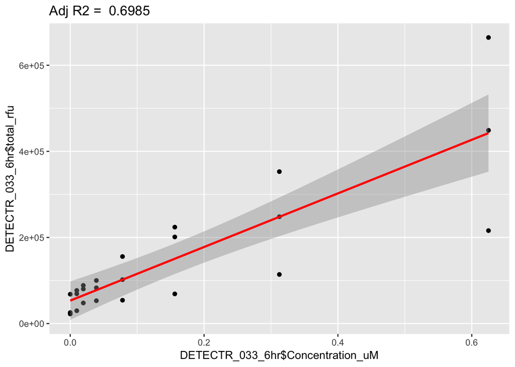

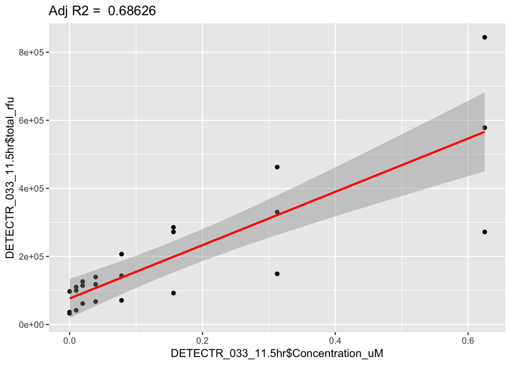

## Buffer comparision at 1hr timepoint, with all concentrations and low concentrations

- First three plots are all concentrations (NEBuffer 4+ 2.1 fresh, NEBuffer 4 fresh and NEBuffer 4 thawed)
- Next three plots are low concentrations (NEBuffer 4+ 2.1 fresh, NEBuffer 4 fresh and NEBuffer 4 thawed)

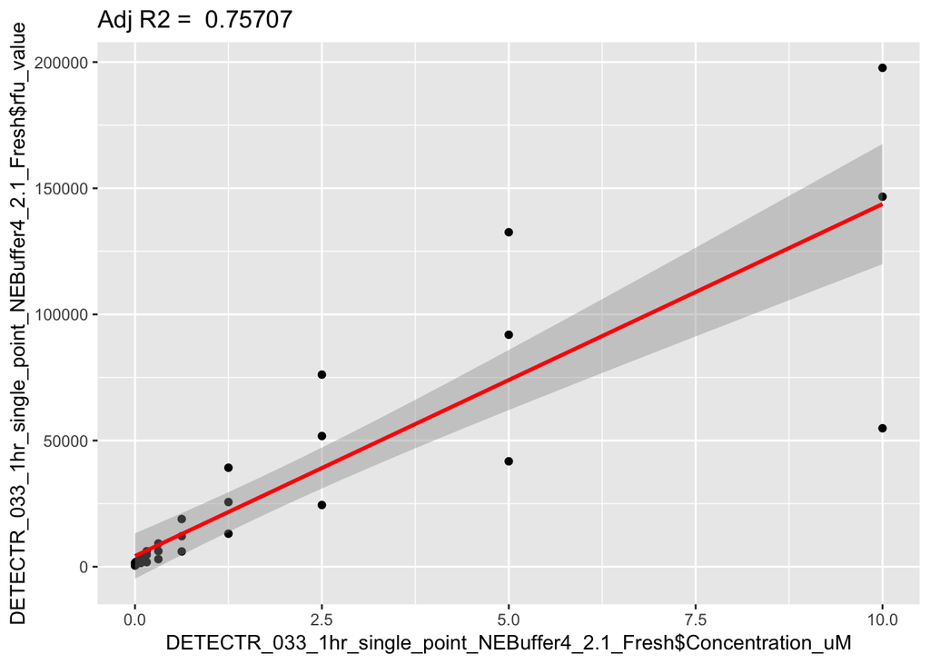

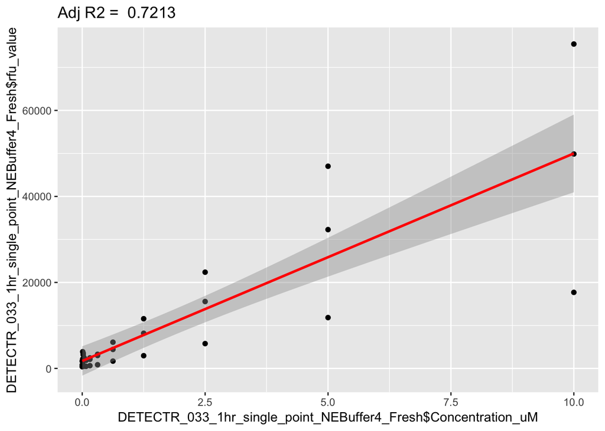

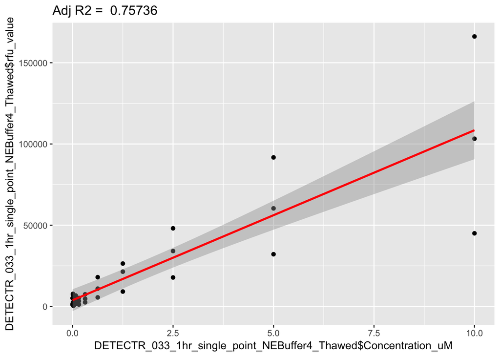

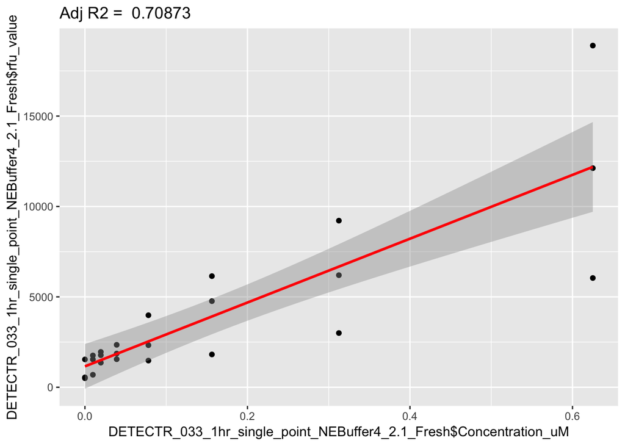

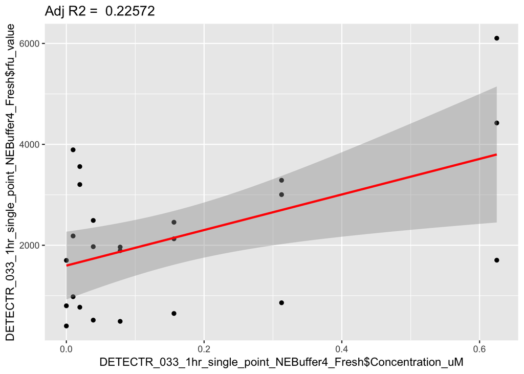

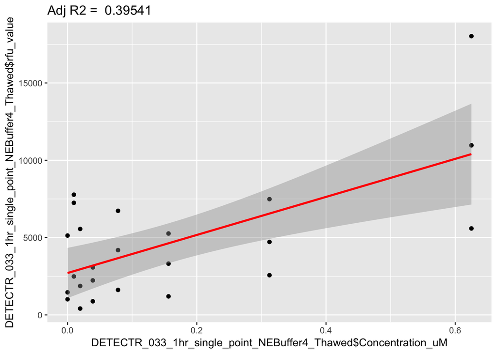